# Stellar Image Classification with Convolutional Neural Networks and Transfer Learning

#### Exploratory Data Analysis

[output not shown]

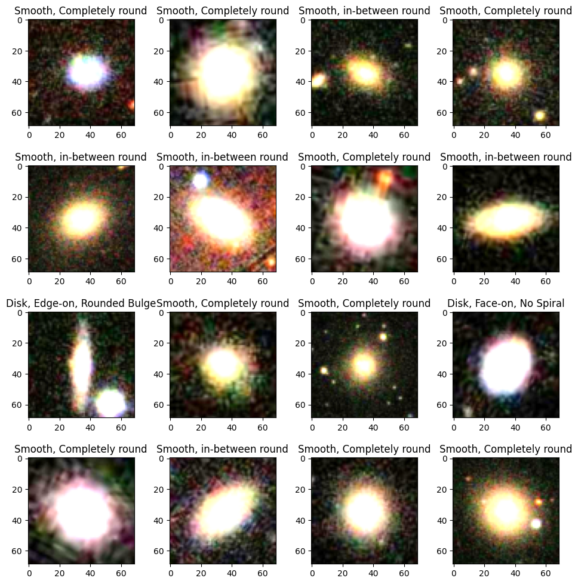

```python
# Plot of the first 16 stellar images
features = ['Disk, Face-on, No Spiral', 'Smooth, Completely round', 'Smooth, in-between round', 'Smooth, Cigar shaped', 'Disk, Edge-on, Rounded Bulge', 'Disk, Edge-on, Boxy Bulge',
            'Disk, Edge-on, No Bulge','Disk, Face-on, Tight Spiral', 'Disk, Face-on, Medium Spiral', 'Disk, Face-on, Loose Spiral']

# 4 by 4 plot of the galaxy Images
fig = plt.figure(figsize=(10, 10))
for i in range(16):
    plt.subplot(4,4,i+1)
    plt.imshow(X_train[i])
    plt.title(features[y_train[i]])
    fig.tight_layout(pad=1.5)
plt.show()
```

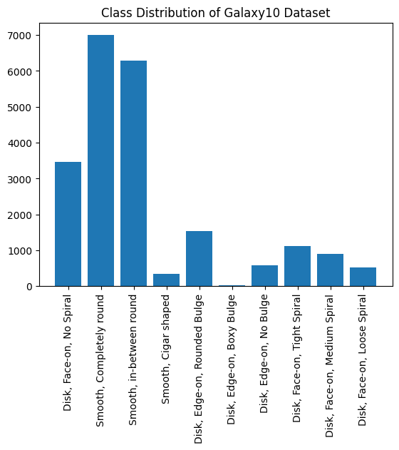

```python
# Plotting the Category Distribution
df = pandas.DataFrame(data=labels)
counts = df.value_counts().sort_index()
# print(counts)
fig, ax = plt.subplots()
ax.bar(features, counts)
ax.set_xticklabels(features, rotation=90)
plt.title("Class Distribution of Galaxy10 Dataset")
plt.show()
```

#### Proposed Approaches (Models)

##### Baseline CNN model (built from scratch)

The below architecture follows a standard pattern of convolutional layers:

```
Conv2D layers with different numbers of filters (32 and 64). The number of filters determines the
complexity of the learned features. With 32 filters in the first Conv2D layer the model can capture
a variety of simple and low-level features such as edges and textures. In the second Conv2D layer with 64
filters the model can learn more complex and high-level features such as shapes and patterns.

Dropout layers randomly set a fraction of input units to 0 during training, which helps to prevent
overfitting. By randomly dropping out units dropout regularization introduces noise to the network
and forces the model to learn more robust and generalizable features. A dropout rate of 0.25 and 0.5 is
applied after the pooling layers and the fully connected layer respectively.

MaxPooling2D layers helps to retain the most salient features while discarding some spatial information.
The softmax activation in the output layer provides the final probability distribution over the 10 galaxy
classes.
```

```python
# Building the layers
modelCNN = Sequential()

modelCNN.add(Conv2D(32, (3, 3), padding='same', input_shape=X_train.shape[1:]))
modelCNN.add(Activation('relu'))
modelCNN.add(MaxPooling2D(pool_size=(2, 2)))
modelCNN.add(Dropout(0.25))

modelCNN.add(Conv2D(64, (3, 3), padding='same'))
modelCNN.add(Activation('relu'))
modelCNN.add(MaxPooling2D(pool_size=(2, 2)))
modelCNN.add(Dropout(0.25))

modelCNN.add(Flatten())
modelCNN.add(Dense(512))
modelCNN.add(Activation('relu'))
modelCNN.add(Dropout(0.5))

modelCNN.add(Dense(10, activation="softmax"))

modelCNN.summary()
```

```
Model: "sequential"
_________________________________________________________________
 Layer (type)                Output Shape              Param #
=================================================================
 conv2d (Conv2D)             (None, 69, 69, 32)        896

 activation (Activation)     (None, 69, 69, 32)        0

 max_pooling2d (MaxPooling2D  (None, 34, 34, 32)       0
 )

 dropout (Dropout)           (None, 34, 34, 32)        0

 conv2d_1 (Conv2D)           (None, 34, 34, 64)        18496

 activation_1 (Activation)   (None, 34, 34, 64)        0

 max_pooling2d_1 (MaxPooling  (None, 17, 17, 64)       0
 2D)

 dropout_1 (Dropout)         (None, 17, 17, 64)        0

 flatten (Flatten)           (None, 18496)             0

 dense (Dense)               (None, 512)               9470464

 activation_2 (Activation)   (None, 512)               0

 dropout_2 (Dropout)         (None, 512)               0

 dense_1 (Dense)             (None, 10)                5130

=================================================================
Total params: 9,494,986
Trainable params: 9,494,986
Non-trainable params: 0
_________________________________________________________________
```

```python
# Compiling the model
modelCNN.compile(loss=keras.losses.SparseCategoricalCrossentropy(from_logits=False), optimizer="adam", metrics=['accuracy'])
```

By including the EarlyStopping callback in the model fitting process the training will be automatically stopped if the validation loss does not improve for the specified number of epochs (in this case 5).

This helps prevent the model from overfitting by avoiding unnecessary training iterations when it's no longer improving its performance on the validation set.

```python
# Setting up early stopping during the training of the LeNet-5 model
early_stopping = EarlyStopping(monitor='val_loss', patience=5, verbose=1, mode='auto')
```

```python
# Training the model
history_CNN = modelCNN.fit(X_train, y_train,
          batch_size=128,
          epochs=10,
          verbose=1,
          validation_data=(X_val, y_val),
          callbacks=early_stopping)
```

```python
# Model Evaluation
```

The Test Loss function quantifies the error or the difference between the predicted values and the true values and the Test accuracy is the proportion of correctly classified instances out of the total number of instances in the test dataset.

```python
# Test data
# Calculating and printing the test loss and test accuracy.
test_scores = modelCNN.evaluate(X_test, y_test, verbose=2)
print('Test loss for baseline CNN Model:', test_scores[0])
print('Test accuracy for baseline CNN Model:', test_scores[1])
```

```
103/103 - 1s - loss: 0.8290 - accuracy: 0.7133 - 1s/epoch - 13ms/step
Test loss for baseline CNN Model: 0.8290476202964783
Test accuracy for baseline CNN Model: 0.7132803201675415
```

```python
# Data to be fed through confusion matrix and classification report
pred = modelCNN.predict(X_test)
indexes = tf.argmax(pred, axis=1)
i = tf.cast([], tf.int32)
indexes = tf.gather_nd(indexes, i)
```

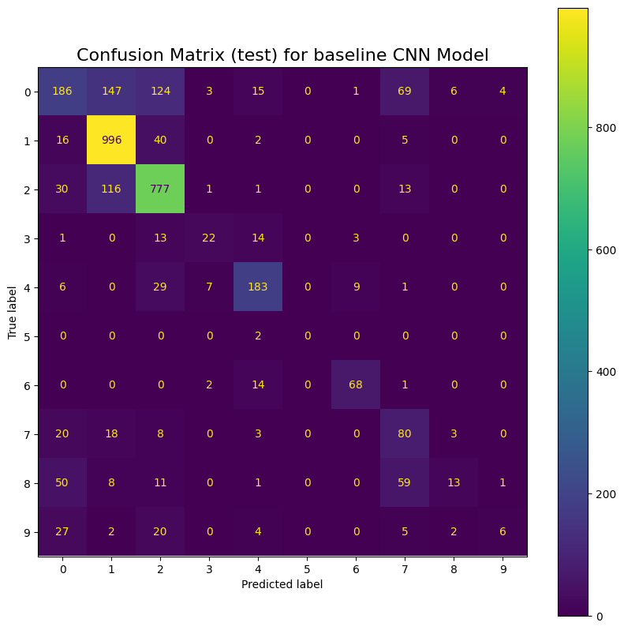

```python
# Creating Confusion Matrix
cm = confusion_matrix(y_test, indexes)
fig = plt.figure(figsize=[10, 10])
ax = fig.add_subplot(1, 1, 1)
c = ConfusionMatrixDisplay(cm, display_labels=range(10))
c.plot(ax = ax)
ax.set_title('Confusion Matrix (test) for baseline CNN Model', fontsize=16)
plt.show()
```

```python
# Printing Classification Report
print("Classification report (test) for baseline CNN Model:\n", classification_report(y_test, indexes))
```

```
Classification report (test) for baseline CNN Model:
               precision    recall  f1-score   support

           0       0.55      0.34      0.42       555
           1       0.77      0.94      0.85      1059
           2       0.76      0.83      0.79       938
           3       0.63      0.42      0.50        53
           4       0.77      0.78      0.77       235
           5       0.00      0.00      0.00         2
           6       0.84      0.80      0.82        85
           7       0.34      0.61      0.44       132
           8       0.54      0.09      0.16       143
           9       0.55      0.09      0.16        66

    accuracy                           0.71      3268
   macro avg       0.58      0.49      0.49      3268
weighted avg       0.70      0.71      0.69      3268
```

From this report, we can tell that our model has a high precision and recall for classifying classes 1, 2, 4 and 6

```python
# Training data
# Calculating and printing the train loss and train accuracy.
train_scores = modelCNN.evaluate(X_train, y_train, verbose=2)
print('Train loss for baseline CNN Model:', train_scores[0])
print('Train accuracy for baseline CNN Model:', train_scores[1])
```

```
477/477 - 6s - loss: 0.5566 - accuracy: 0.7976 - 6s/epoch - 14ms/step
Train loss for baseline CNN Model: 0.5566100478172302
Train accuracy for baseline CNN Model: 0.7976260781288147
```

```python
# Data to be fed through confusion matrix and classification report
pred = modelCNN.predict(X_train)
indexes = tf.argmax(pred, axis=1)
i = tf.cast([], tf.int32)
indexes = tf.gather_nd(indexes, i)
```

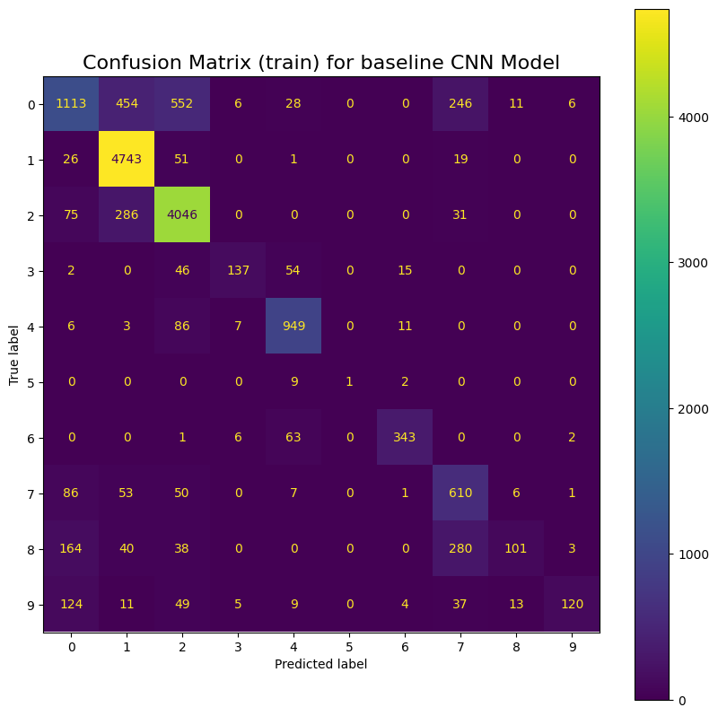

```python
# Creating Confusion Matrix
cm = confusion_matrix(y_train, indexes)
fig = plt.figure(figsize=[10, 10])
ax = fig.add_subplot(1, 1, 1)
c = ConfusionMatrixDisplay(cm, display_labels=range(10))
c.plot(ax = ax)
ax.set_title('Confusion Matrix (train) for baseline CNN Model', fontsize=16)
plt.show()
```

```python
# Printing Classification Report
print("Classification report (train) for baseline CNN Model:\n", classification_report(y_train, indexes))
```

```
Classification report (train) for baseline CNN Model:
               precision    recall  f1-score   support

           0       0.70      0.46      0.55      2416
           1       0.85      0.98      0.91      4840
           2       0.82      0.91      0.86      4438
           3       0.85      0.54      0.66       254
           4       0.85      0.89      0.87      1062
           5       1.00      0.08      0.15        12
           6       0.91      0.83      0.87       415
           7       0.50      0.75      0.60       814
           8       0.77      0.16      0.27       626
           9       0.91      0.32      0.48       372

    accuracy                           0.80     15249
   macro avg       0.82      0.59      0.62     15249
weighted avg       0.80      0.80      0.78     15249
```

We can evaluate the presence of overfitting by analyzing the accuracy vs. iterations plot and the validation loss vs. iterations plot.

Signs of overfitting can be observed when there is a significant difference between the training and validation performance metrics. Specifically if the training accuracy is consistently higher than the validation accuracy or if the validation loss is consistently higher or starts to increase while the training loss decreases.

These discrepancies suggest that the model is likely overfitting the training data and not generalizing well to new data.

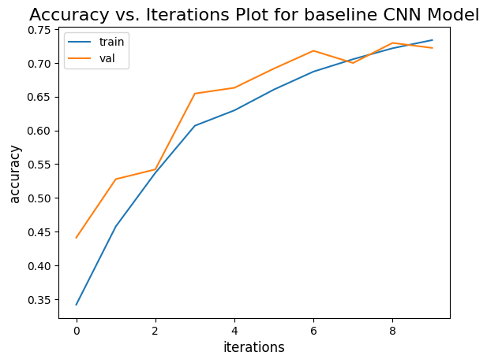

```python
# Checking for overfitting
# Accuracy vs. Iterations Plot
plt.plot(history_CNN.history['accuracy'], label='train')
plt.plot(history_CNN.history['val_accuracy'], label='val')
plt.ylabel('accuracy', fontsize=12)
plt.xlabel('iterations', fontsize=12)
plt.title('Accuracy vs. Iterations Plot for baseline CNN Model', fontsize=16)
plt.legend()
plt.show()
```

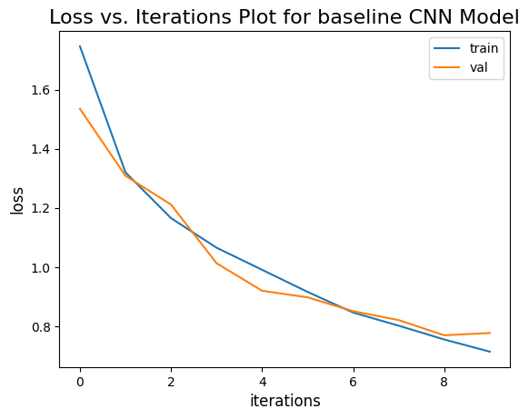

```python
# Validation Loss vs. Iterations Plot
plt.plot(history_CNN.history['loss'], label='train')
plt.plot(history_CNN.history['val_loss'], label='val')
plt.ylabel('loss', fontsize=12)
plt.xlabel('iterations', fontsize=12)
plt.title('Loss vs. Iterations Plot for baseline CNN Model', fontsize=16)
plt.legend()
plt.show()
```

##### LeNet5 Model (built from scratch so not pre-trained)

The below is LeNet-5 architecture proposed by Yann LeCun et al. in 1998 was primarily trained on the MNIST dataset.

However we are building the LeNet-5 architecture from scratch here without utilizing any pre-trained models.

The LeNet-5 architecture utilizes:

```
Convolutional layers (6 filters in the first Conv2D layer and 16 filters in the second) to extract
meaningful features from the input images.
Pooling layers (pool size of (2, 2) and a stride of (2, 2)) to downsample and retain important
information.
Dense layers (1st dense layer has 120 units, 2nd dense layer has 84 units, final dense layer has 10 units)
to learn complex patterns and make class predictions.
The combination of these layers enables the model to effectively classify galaxies based on the learned
representations.
The last dense layer with 10 units represents the output layer of the network. It uses the softmax activation
function to produce a probability distribution over the 10 possible classes.
```

```python
model_LeNet5 = Sequential()

# LeNet-5 conv-net architecture
model_LeNet5.add(Conv2D(filters = 6, kernel_size = (5, 5), strides = (1, 1), activation = 'tanh', input_shape= X_train.shape[1:]))
model_LeNet5.add(AveragePooling2D(pool_size = (2, 2), strides = (2, 2)))
model_LeNet5.add(Conv2D(filters = 16, kernel_size = (5, 5), strides = (1, 1), activation = 'tanh'))
model_LeNet5.add(AveragePooling2D(pool_size = (2, 2), strides = (2, 2)))

model_LeNet5.add(Flatten())
model_LeNet5.add(Dense(units = 120, activation = 'tanh'))
model_LeNet5.add(Dense(units = 84, activation = 'tanh'))
model_LeNet5.add(Dense(units = 10, activation = 'softmax'))

model_LeNet5.summary()
```

```
Model: "sequential_1"
_________________________________________________________________
 Layer (type)                Output Shape              Param #
=================================================================
 conv2d_2 (Conv2D)           (None, 65, 65, 6)         456

 average_pooling2d (AverageP  (None, 32, 32, 6)        0
 ooling2D)

 conv2d_3 (Conv2D)           (None, 28, 28, 16)        2416

 average_pooling2d_1 (Averag  (None, 14, 14, 16)       0
 ePooling2D)

 flatten_1 (Flatten)         (None, 3136)              0

 dense_2 (Dense)             (None, 120)               376440

 dense_3 (Dense)             (None, 84)                10164

 dense_4 (Dense)             (None, 10)                850

=================================================================
Total params: 390,326
Trainable params: 390,326
Non-trainable params: 0
_________________________________________________________________
```

```python
# Setting up early stopping during the training of the LeNet-5 model
early_stopping = EarlyStopping(monitor='val_loss', patience=5, verbose=1, mode='auto')

# Compiling the model
model_LeNet5.compile(loss=keras.losses.SparseCategoricalCrossentropy(from_logits=False), optimizer="adam", metrics=['accuracy'])
```

```python
# Training the model
history_LeNet5 = model_LeNet5.fit(X_train, y_train,
          batch_size=128,
          epochs=10,
          verbose=1,
          validation_data=(X_val, y_val),
          callbacks=early_stopping)
```

```python
# Model Evaluation
```

```python
# Test data
# Calculating and printing the test loss and test accuracy.
test_scores = model_LeNet5.evaluate(X_test, y_test, verbose=2)
print('Test loss for LeNet5 Model:', test_scores[0])
print('Test accuracy for LeNet5 Model:', test_scores[1])
```

```
103/103 - 0s - loss: 0.7906 - accuracy: 0.7243 - 298ms/epoch - 3ms/step
Test loss for LeNet5 Model: 0.7906192541122437
Test accuracy for LeNet5 Model: 0.7242962121963501
```

```python
# Data to be fed through confusion matrix and classification report
pred = model_LeNet5.predict(X_test)
indexes = tf.argmax(pred, axis=1)
i = tf.cast([], tf.int32)
indexes = tf.gather_nd(indexes, i)
```

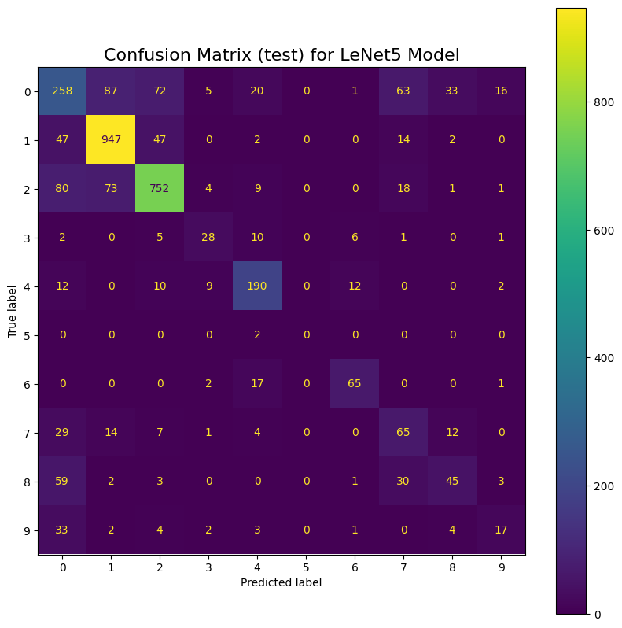

```python
# Creating Confusion Matrix
cm = confusion_matrix(y_test, indexes)
fig = plt.figure(figsize=[10, 10])
ax = fig.add_subplot(1, 1, 1)
c = ConfusionMatrixDisplay(cm, display_labels=range(10))
c.plot(ax = ax)
ax.set_title('Confusion Matrix (test) for LeNet5 Model', fontsize=16)
plt.show()
```

```python
# Printing Classification Report
print("Classification report (test) LeNet5 Model:\n", classification_report(y_test, indexes))
```

```
Classification report (test) LeNet5 Model:
               precision    recall  f1-score   support

           0       0.50      0.46      0.48       555
           1       0.84      0.89      0.87      1059
           2       0.84      0.80      0.82       938
           3       0.55      0.53      0.54        53
           4       0.74      0.81      0.77       235
           5       0.00      0.00      0.00         2
           6       0.76      0.76      0.76        85
           7       0.34      0.49      0.40       132
           8       0.46      0.31      0.38       143
           9       0.41      0.26      0.32        66

    accuracy                           0.72      3268
   macro avg       0.54      0.53      0.53      3268
weighted avg       0.72      0.72      0.72      3268
```

```python
# Training data
# Calculating and printing the train loss and train accuracy.
train_scores = model_LeNet5.evaluate(X_train, y_train, verbose=2)
print('Train loss for baseline LeNet5 Model:', train_scores[0])
print('Train accuracy for baseline LeNet5 Model:', train_scores[1])
```

```
477/477 - 2s - loss: 0.3230 - accuracy: 0.8966 - 2s/epoch - 5ms/step
Train loss for baseline LeNet5 Model: 0.3229789137840271
Train accuracy for baseline LeNet5 Model: 0.8966489434242249
```

```python
# Data to be fed through confusion matrix and classification report
pred = model_LeNet5.predict(X_train)
indexes = tf.argmax(pred, axis=1)
i = tf.cast([], tf.int32)
indexes = tf.gather_nd(indexes, i)
```

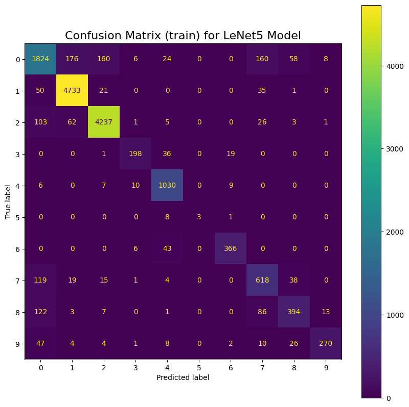

```python
# Creating Confusion Matrix
cm = confusion_matrix(y_train, indexes)
fig = plt.figure(figsize=[10, 10])
ax = fig.add_subplot(1, 1, 1)
c = ConfusionMatrixDisplay(cm, display_labels=range(10))
c.plot(ax = ax)
ax.set_title('Confusion Matrix (train) for LeNet5 Model', fontsize=16)
plt.show()
```

```python
# Printing Classification Report
print("Classification report (train) LeNet5 Model:\n", classification_report(y_train, indexes))
```

```
Classification report (train) LeNet5 Model:
               precision    recall  f1-score   support

           0       0.80      0.75      0.78      2416
           1       0.95      0.98      0.96      4840
           2       0.95      0.95      0.95      4438
           3       0.89      0.78      0.83       254
           4       0.89      0.97      0.93      1062
           5       1.00      0.25      0.40        12
           6       0.92      0.88      0.90       415
           7       0.66      0.76      0.71       814
           8       0.76      0.63      0.69       626
           9       0.92      0.73      0.81       372

    accuracy                           0.90     15249
   macro avg       0.87      0.77      0.80     15249
weighted avg       0.90      0.90      0.90     15249
```

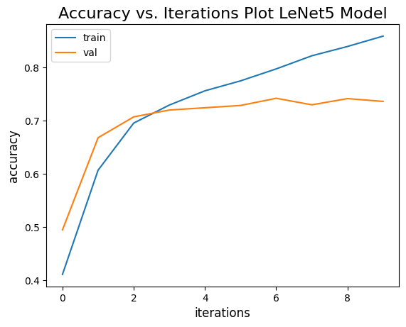

```python
# Checking for overfitting
# Accuracy vs. Iterations Plot
plt.plot(history_LeNet5.history['accuracy'], label='train')
plt.plot(history_LeNet5.history['val_accuracy'], label='val')
plt.ylabel('accuracy', fontsize=12)
plt.xlabel('iterations', fontsize=12)
plt.title('Accuracy vs. Iterations Plot LeNet5 Model', fontsize=16)
plt.legend()
plt.show()
```

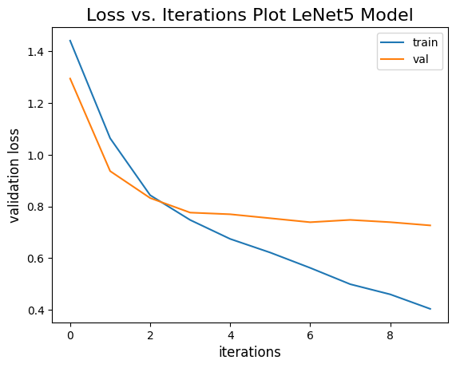

```python
# Validation Loss vs. Iterations Plot
plt.plot(history_LeNet5.history['loss'], label='train')
plt.plot(history_LeNet5.history['val_loss'], label='val')
plt.ylabel('validation loss', fontsize=12)
plt.xlabel('iterations', fontsize=12)
plt.title('Loss vs. Iterations Plot LeNet5 Model', fontsize=16)
plt.legend()
plt.show()
```

##### VGG16 Model with Transfer Learning

```python
# Create the base VGG16 model
VGG16_model = VGG16(weights='imagenet', include_top=False, input_shape=X_train.shape[1:])
model_VGG16 = Sequential()
```

Since we want to use the architecture and pre-trained weights of a pre-existing model (VGG16) as a starting point or a base for building a new model.

By reusing the pre-trained layers we can benefit from the learned features and representations without having to train the entire model from scratch. This part is commonly known as transfer learning.

```python
# Adding all the layers of a pre-trained VGG16 model to a new model called model_VGG16
for layer in VGG16_model.layers:
  model_VGG16.add(layer)
```

The purpose of freezing the base model layers in transfer learning is to prevent them from being updated or trained during the training process of the transfer learning model.

By freezing the base model layers we retain the pre-trained weights and feature extraction capabilities of the base model allowing us to focus on training only the added layers (in this case the custom Dense layers and the output layer).

```python
# Freezing the weights of the base model layers
for layer in model_VGG16.layers:
  layer.trainable = False
```

By adding the Flatten() layer to the VGG16 model we ensure that the output of the last pooling layer is flattened before feeding it to the subsequent Dense layers.

This correctly shapes the input for the subsequent layers and enabling the model to learn from the extracted features.

The additional Dense layers are introduced to further adapt the pre-trained model to the specific classification task of galaxies.

By adding a dense layer with 512 units we are increasing the model's capacity to learn and represent complex patterns and relationships in the galaxy images. The larger the number of units the more expressive power the layer has to capture intricate features specific to galaxy classification.

The additional dense layers further refine the model's ability to learn and represent more specific features and patterns relevant to galaxy images.

By gradually reducing the number of units we introduce a level of dimensionality reduction allowing the model to focus on more compact and concise representations.

The activation function "softmax" produces a probability distribution over the classes enabling multi-class classification.

```python
# Adding a Flatten() layer to the VGG16 model when setting it up for transfer learning.
model_VGG16.add(Flatten())
# Add custom Dense layers on top of the base model to perform transfer learning
model_VGG16.add(Dense(512))
model_VGG16.add(Dense(64))
model_VGG16.add(Dense(32))
# Add the output layer with softmax activation.
# Note the 10 in the output layer is the number of classes or categories in our classification problem
model_VGG16.add(Dense(10, activation="softmax"))

model_VGG16.summary()
```

```
Model: "sequential_2"
_________________________________________________________________
 Layer (type)                Output Shape              Param #
=================================================================
 block1_conv1 (Conv2D)       (None, 69, 69, 64)        1792

 block1_conv2 (Conv2D)       (None, 69, 69, 64)        36928

 block1_pool (MaxPooling2D)  (None, 34, 34, 64)        0

 block2_conv1 (Conv2D)       (None, 34, 34, 128)       73856

 block2_conv2 (Conv2D)       (None, 34, 34, 128)       147584

 block2_pool (MaxPooling2D)  (None, 17, 17, 128)       0

 block3_conv1 (Conv2D)       (None, 17, 17, 256)       295168

 block3_conv2 (Conv2D)       (None, 17, 17, 256)       590080

 block3_conv3 (Conv2D)       (None, 17, 17, 256)       590080

 block3_pool (MaxPooling2D)  (None, 8, 8, 256)         0

 block4_conv1 (Conv2D)       (None, 8, 8, 512)         1180160

 block4_conv2 (Conv2D)       (None, 8, 8, 512)         2359808

 block4_conv3 (Conv2D)       (None, 8, 8, 512)         2359808

 block4_pool (MaxPooling2D)  (None, 4, 4, 512)         0

 block5_conv1 (Conv2D)       (None, 4, 4, 512)         2359808

 block5_conv2 (Conv2D)       (None, 4, 4, 512)         2359808

 block5_conv3 (Conv2D)       (None, 4, 4, 512)         2359808

 block5_pool (MaxPooling2D)  (None, 2, 2, 512)         0

 flatten_2 (Flatten)         (None, 2048)              0

 dense_5 (Dense)             (None, 512)               1049088

 dense_6 (Dense)             (None, 64)                32832

 dense_7 (Dense)             (None, 32)                2080

 dense_8 (Dense)             (None, 10)                330

=================================================================
Total params: 15,799,018
Trainable params: 1,084,330
Non-trainable params: 14,714,688
_________________________________________________________________
```

```python
# Compiling the new model
model_VGG16.compile(loss=keras.losses.SparseCategoricalCrossentropy(from_logits=False), optimizer="adam", metrics=['accuracy'])

# Setting up early stopping during the training of a VGG16 model with transfer learning
early_stopping = EarlyStopping(monitor='val_loss', patience=5, verbose=1, mode='auto')
```

```python
# Training the new model
history_VGG16 = model_VGG16.fit(X_train, y_train,
          batch_size=128,
          epochs=10,
          verbose=1,
          validation_data=(X_val, y_val),
          callbacks=early_stopping)
```

```python
# Model Evaluation
```

```python
# Test data
# Calculating and printing the test loss and test accuracy.
test_scores = model_VGG16.evaluate(X_test, y_test, verbose=2)
print('Test loss for VGG16 Model with TL:', test_scores[0])
print('Test accuracy for VGG16 Model with TL:', test_scores[1])
```

```
103/103 - 27s - loss: 0.7924 - accuracy: 0.7191 - 27s/epoch - 265ms/step
Test loss for VGG16 Model with TL: 0.7923672795295715
Test accuracy for VGG16 Model with TL: 0.7190942764282227
```

```python
# Data to be fed through confusion matrix and classification report
pred = model_VGG16.predict(X_test)
indexes = tf.argmax(pred, axis=1)
i = tf.cast([], tf.int32)
indexes = tf.gather_nd(indexes, i)
```

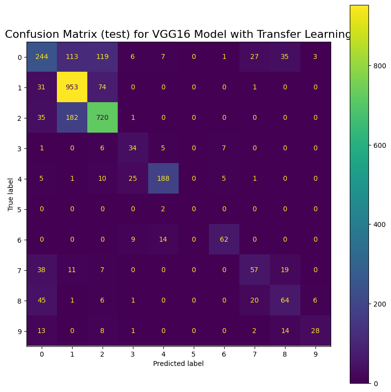

```python
# Creating the Confusion Matrix
cm = confusion_matrix(y_test, indexes)
fig = plt.figure(figsize=[10, 10])
ax = fig.add_subplot(1, 1, 1)
c = ConfusionMatrixDisplay(cm, display_labels=range(10))
c.plot(ax = ax)
ax.set_title('Confusion Matrix (test) for VGG16 Model with Transfer Learning', fontsize=16)
plt.show()
```

```python
# Printing the Classification Report
print("Classification report (test) for VGG16 Model with Transfer Learning:\n", classification_report(y_test, indexes))
```

```
Classification report (test) for VGG16 Model with Transfer Learning:
               precision    recall  f1-score   support

           0       0.59      0.44      0.50       555
           1       0.76      0.90      0.82      1059
           2       0.76      0.77      0.76       938
           3       0.44      0.64      0.52        53
           4       0.87      0.80      0.83       235
           5       0.00      0.00      0.00         2
           6       0.83      0.73      0.77        85
           7       0.53      0.43      0.48       132
           8       0.48      0.45      0.47       143
           9       0.76      0.42      0.54        66

    accuracy                           0.72      3268
   macro avg       0.60      0.56      0.57      3268
weighted avg       0.71      0.72      0.71      3268
```

```python
# Training data
# Calculating and printing the train loss and train accuracy.
train_scores = model_VGG16.evaluate(X_train, y_train, verbose=2)
print('Train loss for VGG16 Model with TL:', train_scores[0])
print('Train accuracy for VGG16 Model with TL:', train_scores[1])
```

```
477/477 - 143s - loss: 0.5429 - accuracy: 0.7900 - 143s/epoch - 299ms/step
Train loss for VGG16 Model with TL: 0.5429041981697083
Train accuracy for VGG16 Model with TL: 0.7899534106254578
```

```python
# Data to be fed through confusion matrix and classification report
pred = model_VGG16.predict(X_train)
indexes = tf.argmax(pred, axis=1)
i = tf.cast([], tf.int32)
indexes = tf.gather_nd(indexes, i)
```

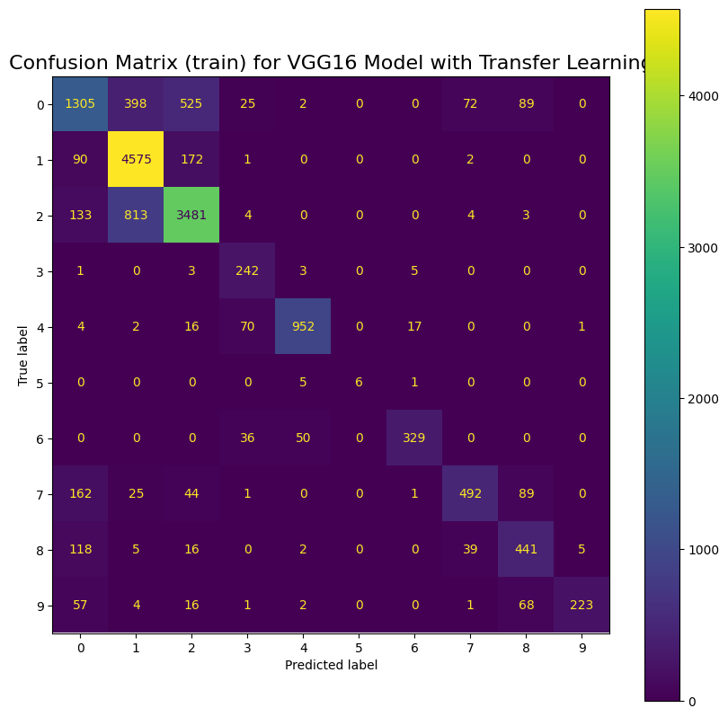

```python
# Creating the Confusion Matrix
cm = confusion_matrix(y_train, indexes)
fig = plt.figure(figsize=[10, 10])
ax = fig.add_subplot(1, 1, 1)
c = ConfusionMatrixDisplay(cm, display_labels=range(10))
c.plot(ax = ax)
ax.set_title('Confusion Matrix (train) for VGG16 Model with Transfer Learning', fontsize=16)
plt.show()
```

```python
# Printing the Classification Report
print("Classification report (train) for VGG16 Model with Transfer Learning:\n", classification_report(y_train, indexes))
```

```
Classification report (train) for VGG16 Model with Transfer Learning:
               precision    recall  f1-score   support

           0       0.70      0.54      0.61      2416
           1       0.79      0.95      0.86      4840
           2       0.81      0.78      0.80      4438
           3       0.64      0.95      0.76       254
           4       0.94      0.90      0.92      1062
           5       1.00      0.50      0.67        12
           6       0.93      0.79      0.86       415
           7       0.81      0.60      0.69       814
           8       0.64      0.70      0.67       626
           9       0.97      0.60      0.74       372

    accuracy                           0.79     15249
   macro avg       0.82      0.73      0.76     15249
weighted avg       0.79      0.79      0.78     15249
```

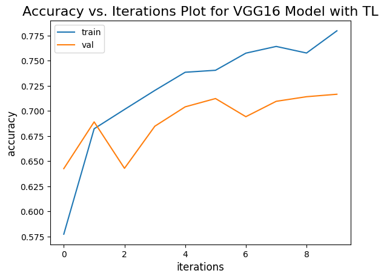

```python
# Checking for overfitting
# Accuracy vs. Iterations Plot
plt.plot(history_VGG16.history['accuracy'], label='train')
plt.plot(history_VGG16.history['val_accuracy'], label='val')
plt.ylabel('accuracy', fontsize=12)
plt.xlabel('iterations', fontsize=12)
plt.title('Accuracy vs. Iterations Plot for VGG16 Model with TL', fontsize=16)
plt.legend()
plt.show()
```

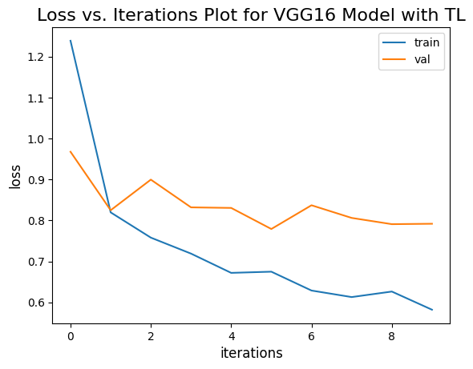

```python
# Validation Loss vs. Iterations Plot
plt.plot(history_VGG16.history['loss'], label='train')
plt.plot(history_VGG16.history['val_loss'], label='val')
plt.ylabel('loss', fontsize=12)
plt.xlabel('iterations', fontsize=12)
plt.title('Loss vs. Iterations Plot for VGG16 Model with TL', fontsize=16)
plt.legend()
plt.show()
```

##### VGG19 Model with Transfer Learning

```python
# Create the base VGG19 model
VGG19_model = VGG19(weights='imagenet', include_top=False, input_shape=X_train.shape[1:])
model_VGG19 = Sequential()
```

```python
# Adding all the layers of a pre-trained VGG19 model to a new model called model_VGG19
for layer in VGG19_model.layers:
  model_VGG19.add(layer)
```

```python
# Freezing the weights of the base model layers
for layer in model_VGG19.layers:
  layer.trainable = False
```

These additional dense layers increase the model's capacity to learn complex relationships and features from the galaxy images.

Adding a dense layer with 1024 units increases the model's capacity to capture complex patterns. This larger number of units allows the layer to learn more intricate and fine-grained representations of the image features potentially improving the model's ability to discriminate between different types of galaxies.

The smaller numbers of units continue the process of dimensionality reduction and abstraction. They help the model focus on more compact and higher-level representations of the galaxy images

The activation function "softmax" produces a probability distribution over the classes enabling multi-class classification.

```python
# Adding a Flatten() layer to the VGG16 model when setting it up for transfer learning.
model_VGG19.add(Flatten())
# Add custom Dense layers on top of the base model to perform transfer learning
model_VGG19.add(Dense(1024))
model_VGG19.add(Dense(512))
model_VGG19.add(Dense(64))
model_VGG19.add(Dense(32))
# Add the output layer with softmax activation.
# Note the 10 in the output layer is the number of classes or categories in our classification problem
model_VGG19.add(Dense(10, activation="softmax"))

model_VGG19.summary()
```

```
Model: "sequential_3"
_________________________________________________________________
 Layer (type)                Output Shape              Param #
=================================================================
 block1_conv1 (Conv2D)       (None, 69, 69, 64)        1792

 block1_conv2 (Conv2D)       (None, 69, 69, 64)        36928

 block1_pool (MaxPooling2D)  (None, 34, 34, 64)        0

 block2_conv1 (Conv2D)       (None, 34, 34, 128)       73856

 block2_conv2 (Conv2D)       (None, 34, 34, 128)       147584

 block2_pool (MaxPooling2D)  (None, 17, 17, 128)       0

 block3_conv1 (Conv2D)       (None, 17, 17, 256)       295168

 block3_conv2 (Conv2D)       (None, 17, 17, 256)       590080

 block3_conv3 (Conv2D)       (None, 17, 17, 256)       590080

 block3_conv4 (Conv2D)       (None, 17, 17, 256)       590080

 block3_pool (MaxPooling2D)  (None, 8, 8, 256)         0

 block4_conv1 (Conv2D)       (None, 8, 8, 512)         1180160

 block4_conv2 (Conv2D)       (None, 8, 8, 512)         2359808

 block4_conv3 (Conv2D)       (None, 8, 8, 512)         2359808

 block4_conv4 (Conv2D)       (None, 8, 8, 512)         2359808

 block4_pool (MaxPooling2D)  (None, 4, 4, 512)         0

 block5_conv1 (Conv2D)       (None, 4, 4, 512)         2359808

 block5_conv2 (Conv2D)       (None, 4, 4, 512)         2359808

```

[output cut: 8 more lines]

```
 dense_9 (Dense)             (None, 1024)              2098176

 dense_10 (Dense)            (None, 512)               524800

 dense_11 (Dense)            (None, 64)                32832

 dense_12 (Dense)            (None, 32)                2080

 dense_13 (Dense)            (None, 10)                330

=================================================================
Total params: 22,682,602
Trainable params: 2,658,218
Non-trainable params: 20,024,384
_________________________________________________________________
```

```python
# Compiling the new model
model_VGG19.compile(loss=keras.losses.SparseCategoricalCrossentropy(from_logits=False), optimizer="adam", metrics=['accuracy'])

# Setting up early stopping during the training of a VGG16 model with transfer learning
early_stopping = EarlyStopping(monitor='val_loss', patience=5, verbose=1, mode='auto')
```

```python
# Training the new model
history_VGG19 = model_VGG19.fit(X_train, y_train,
          batch_size=128,
          epochs=10,
          verbose=1,
          validation_data=(X_val, y_val),
          callbacks=early_stopping)
```

```
Epoch 10: early stopping
```

```python
# Model Evaluation
```

```python
# Test data
# Calculating and printing the test loss and test accuracy.
test_scores = model_VGG19.evaluate(X_test, y_test, verbose=2)
print('Test loss for VGG19 Model with TL:', test_scores[0])
print('Test accuracy for VGG19 Model with TL:', test_scores[1])
```

```
103/103 - 31s - loss: 0.9464 - accuracy: 0.6597 - 31s/epoch - 297ms/step
Test loss for VGG19 Model with TL: 0.9464378952980042
Test accuracy for VGG19 Model with TL: 0.6597307324409485
```

```python
# Data to be fed through confusion matrix and classification report
pred = model_VGG19.predict(X_test)
indexes = tf.argmax(pred, axis=1)
i = tf.cast([], tf.int32)
indexes = tf.gather_nd(indexes, i)
```

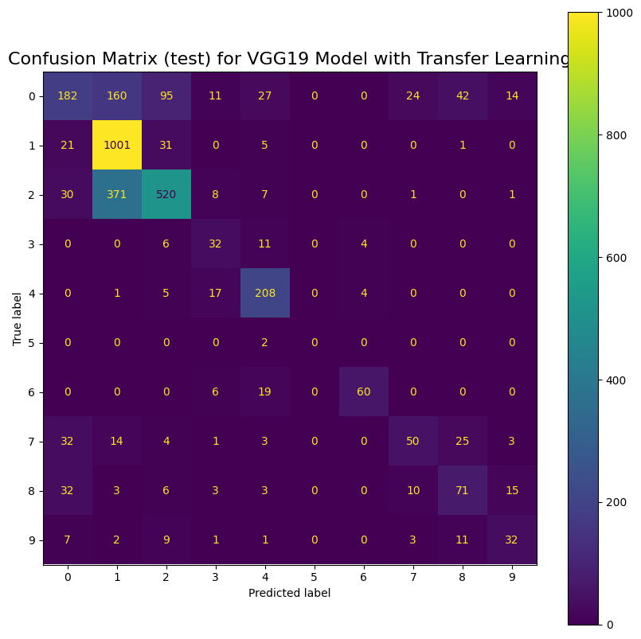

```python
# Creating the Confusion Matrix
cm = confusion_matrix(y_test, indexes)
fig = plt.figure(figsize=[10, 10])
ax = fig.add_subplot(1, 1, 1)
c = ConfusionMatrixDisplay(cm, display_labels=range(10))
c.plot(ax = ax)
ax.set_title('Confusion Matrix (test) for VGG19 Model with Transfer Learning', fontsize=16)
plt.show()
```

```python
# Printing the Classification Report
print("Classification report (test) for VGG19 Model with Transfer Learning:\n", classification_report(y_test, indexes))
```

```
Classification report (test) for VGG19 Model with Transfer Learning:
               precision    recall  f1-score   support

           0       0.60      0.33      0.42       555
           1       0.64      0.95      0.77      1059
           2       0.77      0.55      0.64       938
           3       0.41      0.60      0.48        53
           4       0.73      0.89      0.80       235
           5       0.00      0.00      0.00         2
           6       0.88      0.71      0.78        85
           7       0.57      0.38      0.45       132
           8       0.47      0.50      0.48       143
           9       0.49      0.48      0.49        66

    accuracy                           0.66      3268
   macro avg       0.56      0.54      0.53      3268
weighted avg       0.67      0.66      0.64      3268
```

```python
# Training data
# Calculating and printing the train loss and train accuracy.
train_scores = model_VGG19.evaluate(X_train, y_train, verbose=2)
print('Train loss for VGG19 Model with TL:', train_scores[0])
print('Train accuracy for VGG19 Model with TL:', train_scores[1])
```

```
477/477 - 143s - loss: 0.7340 - accuracy: 0.7087 - 143s/epoch - 299ms/step
Train loss for VGG19 Model with TL: 0.734004557132721
Train accuracy for VGG19 Model with TL: 0.7087022066116333
```

```python
# Data to be fed through confusion matrix and classification report
pred = model_VGG19.predict(X_train)
indexes = tf.argmax(pred, axis=1)
i = tf.cast([], tf.int32)
indexes = tf.gather_nd(indexes, i)
```

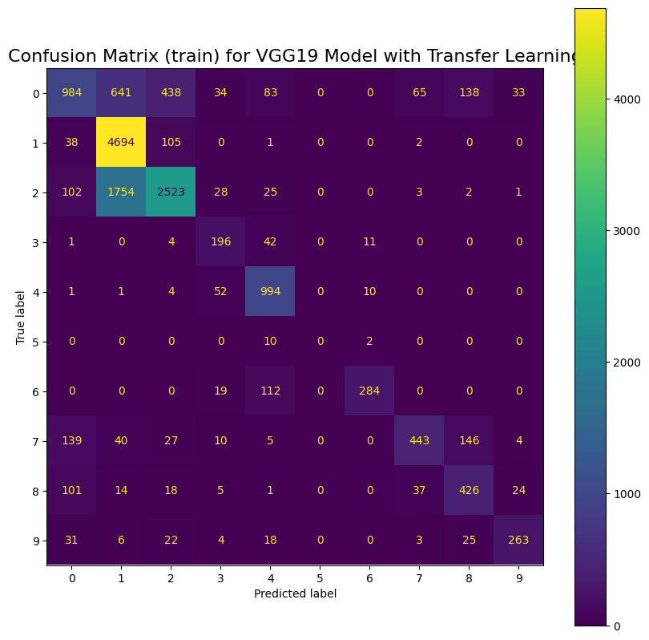

```python
# Creating the Confusion Matrix
cm = confusion_matrix(y_train, indexes)
fig = plt.figure(figsize=[10, 10])
ax = fig.add_subplot(1, 1, 1)
c = ConfusionMatrixDisplay(cm, display_labels=range(10))
c.plot(ax = ax)
ax.set_title('Confusion Matrix (train) for VGG19 Model with Transfer Learning', fontsize=16)
plt.show()
```

```python
# Printing the Classification Report
print("Classification report (train) for VGG19 Model with Transfer Learning:\n", classification_report(y_train, indexes))
```

```
Classification report (train) for VGG19 Model with Transfer Learning:
               precision    recall  f1-score   support

           0       0.70      0.41      0.52      2416
           1       0.66      0.97      0.78      4840
           2       0.80      0.57      0.67      4438
           3       0.56      0.77      0.65       254
           4       0.77      0.94      0.84      1062
           5       0.00      0.00      0.00        12
           6       0.93      0.68      0.79       415
           7       0.80      0.54      0.65       814
           8       0.58      0.68      0.63       626
           9       0.81      0.71      0.75       372

    accuracy                           0.71     15249
   macro avg       0.66      0.63      0.63     15249
weighted avg       0.73      0.71      0.69     15249
```

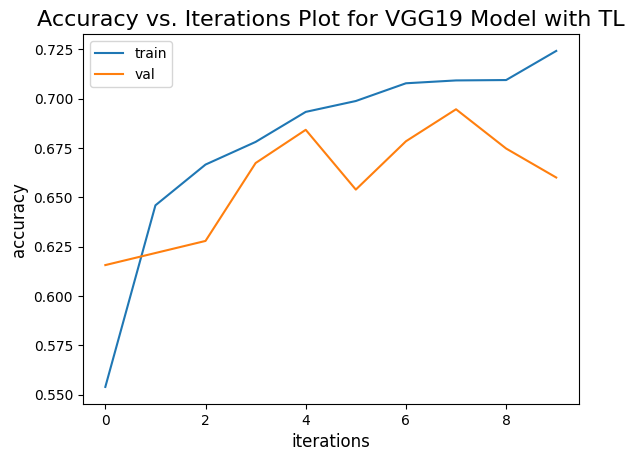

```python
# Checking for overfitting
# Accuracy vs. Iterations Plot
plt.plot(history_VGG19.history['accuracy'], label='train')
plt.plot(history_VGG19.history['val_accuracy'], label='val')
plt.ylabel('accuracy', fontsize=12)
plt.xlabel('iterations', fontsize=12)
plt.title('Accuracy vs. Iterations Plot for VGG19 Model with TL', fontsize=16)
plt.legend()
plt.show()
```

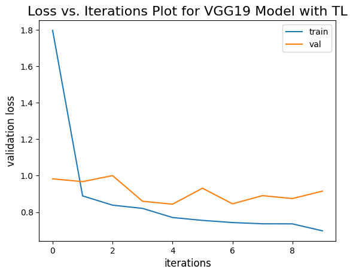

```python
# Validation Loss vs. Iterations Plot
plt.plot(history_VGG19.history['loss'], label='train')
plt.plot(history_VGG19.history['val_loss'], label='val')
plt.ylabel('validation loss', fontsize=12)
plt.xlabel('iterations', fontsize=12)
plt.title('Loss vs. Iterations Plot for VGG19 Model with TL', fontsize=16)
plt.legend()
plt.show()
```